# Salmon Group Task

Ian Brunjes, Gavriella Keyles, Dani Sclafani

2/3/2021

## Overview

Fish species traveling through Willamette river to the Columbia River Basin are recorded daily. Steelhead, Coho, and Jack Coho salmon are three of the species recorded by Columbia Basin Research. The dataset used in this exploration includes the number of fish observed daily, for each fish species from 2001-2010.<sup>1</sup> This report attempts to find seasonal and overall trends of the number of each fish species observed traveling from the Wilamette River to the Columbia river using time series modeling.

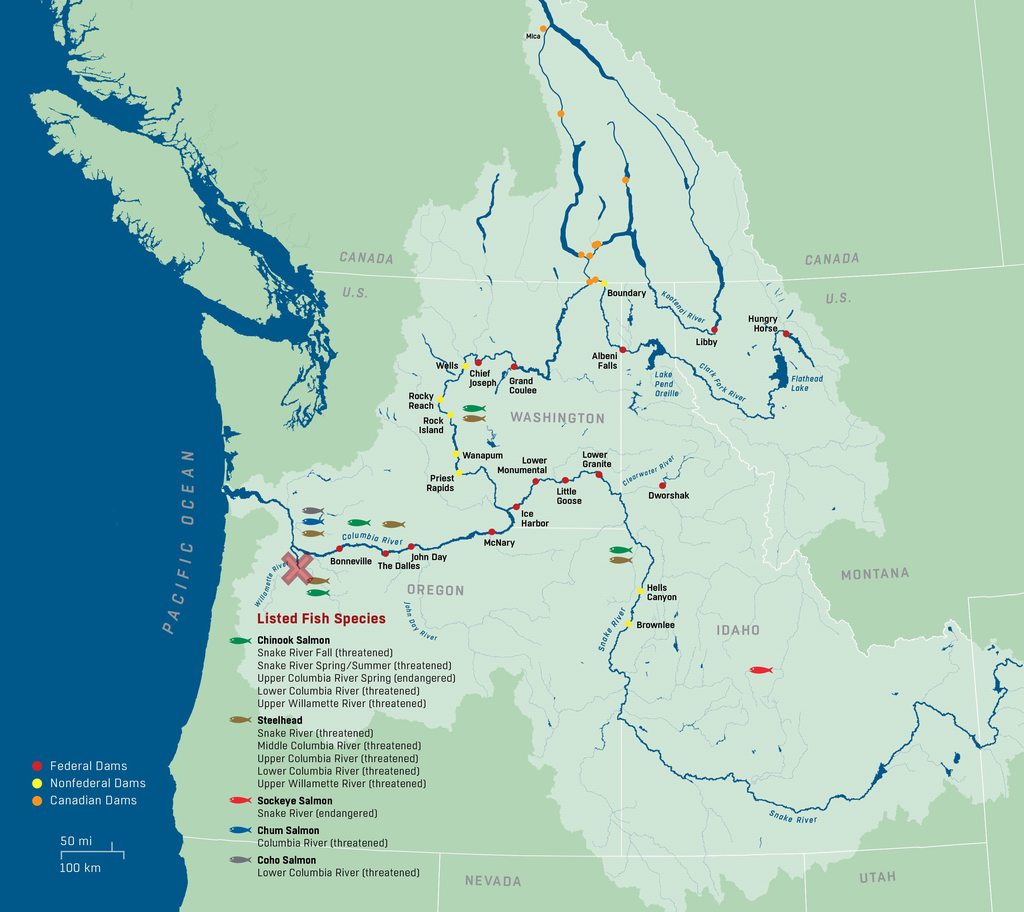

Image 1.0: Map of Columbia River basin, displaying the Willamette River in the top left corner of Oregon and its connection to the Columbia River. The fish species present in the rivers feeding into the Columbia River basin are listed, including the status of the species, either endangered or threatened.<sup>2</sup>

```r
knitr::include_graphics(here("river_map.jpeg"))
```

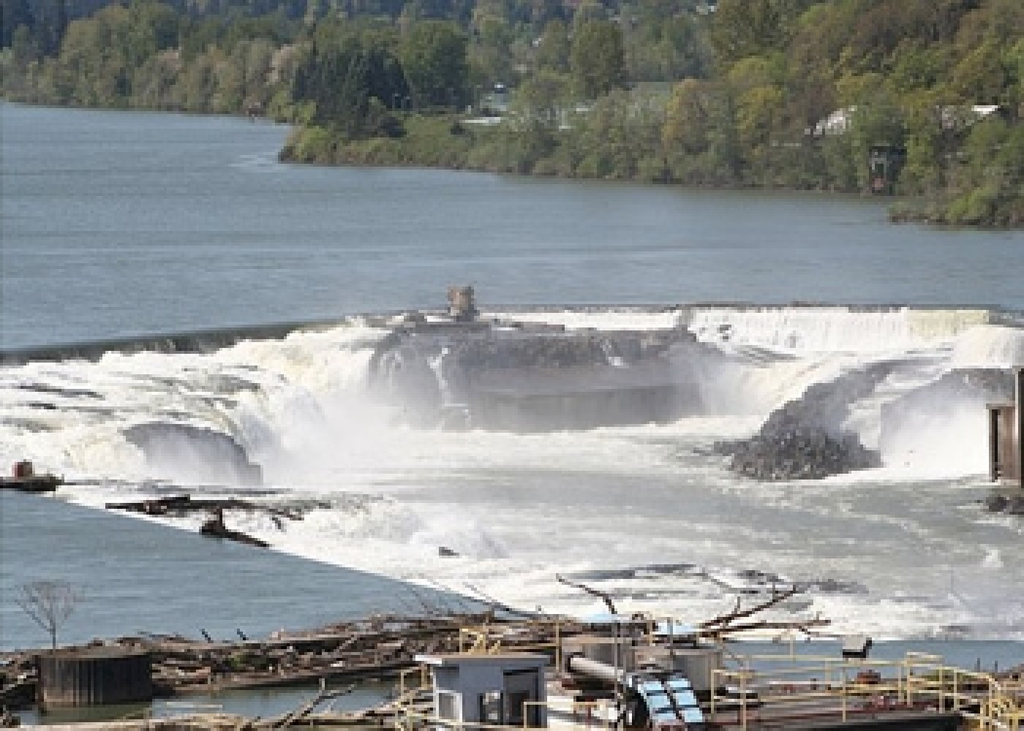

Image 2.0: Willamette Falls, Oregon. The site of the fish ladder where daily counts of passing salmon are collected and aggregated.<sup>3</sup>

```r
knitr::include_graphics(here("willamette_falls.jpg"))
```

## Data Analysis

### Original Time Series

```r
# Read in salmon data from csv and clean names
salmon_data_full <- read_csv(here("data", "willamette_fish_passage.csv"))%>%
  clean_names()
```

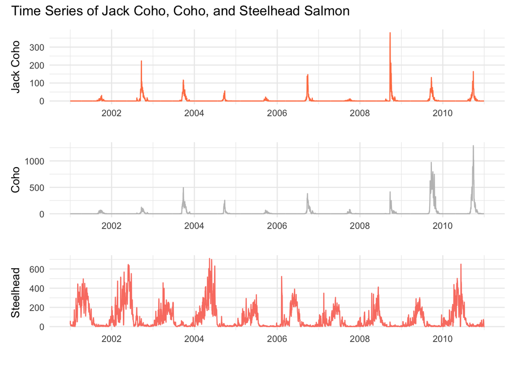

```r
#initial wrangling, selecting for desired species, making sure salmon columns are numeric and NAs are replaced with 0. Also converting date column from a character class to a date character using lubridate package
tab1_data <- salmon_data_full %>%
  select("steelhead", "coho", "jack_coho", "date") %>%
  mutate_all(~replace(., is.na(.), 0)) %>%
  mutate(date = mdy(date)) %>%
  mutate(year = year(date))

# creating column of total sum of salmon
tab1_data$salmon_sum <- rowSums(tab1_data[,1:3], na.rm = TRUE)

#making data into a time series using tsibble
tab1_ts <- tab1_data %>%
  mutate(yearmonth = tsibble:: yearmonth(date)) %>%
  as_tibble(key = NULL, index = yearmonth)


# visualizing the time series data
#steelheads
sh_graph <- ggplot(data = tab1_ts, aes(x = date, y = steelhead ))+
  geom_line(color = "salmon") +
  labs(x = " ", y = "Steelhead")+
  theme_minimal()


#coho
coho_graph <- ggplot(data = tab1_ts, aes(x = date, y = coho ))+
  geom_line(color = "gray75")+
  labs(x = " ", y = "Coho")+
  theme_minimal()

# jack coho
jcoho_graph <- ggplot(data = tab1_ts, aes(x = date, y = jack_coho ))+
  geom_line(color = "coral")+
  labs(x = " ", y = "Jack Coho")+
  theme_minimal()

total_graph <- jcoho_graph / coho_graph / sh_graph

# output final plot and adjust styles
total_graph +plot_layout() +
  plot_annotation(title = "Time Series of Jack Coho, Coho, and Steelhead Salmon") +
  theme(plot.title = element_text(hjust =0.5))
```

### Seasonplots

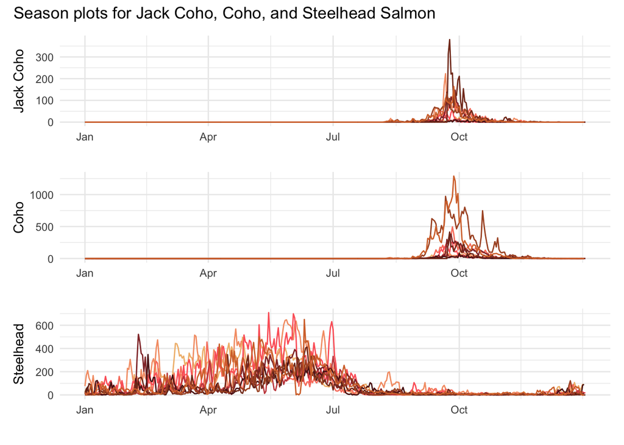

Figure 2: Jack Coho, Coho, and Steelhead salmon seasonal observations for years 2001-2010 in Willamette Falls, Oregon.

```r
# Massage data for time series
season_data <- salmon_data_full %>%
  mutate_all(~replace(., is.na(.), 0)) %>%
  mutate(datetime = mdy(date)) %>%
  mutate(coho = as.numeric(coho)) %>%
  mutate(jack_coho = as.numeric(jack_coho)) %>%
  mutate(steelhead = as.numeric(steelhead))

# Create tsibble for coho data subset
coho_ts <- season_data %>%
  select(datetime, coho) %>%
  as_tsibble(key = NULL, index = datetime)

# Create tsibble for jack coho data subset
jack_coho_ts <- season_data %>%
  select(datetime, jack_coho) %>%
  as_tsibble(key = NULL, index = datetime)

# Create tsibble for steelhead data subset
steelhead_ts <- season_data %>%
  select(datetime, steelhead) %>%
  as_tsibble(key = NULL, index = datetime)

# Build season plots for each species
coho <- coho_ts %>% gg_season(pal= wes_palette("GrandBudapest1", type = "continuous", 10)) +
  theme_minimal() +
  theme(legend.position = "none") +
  labs(y = "Coho", x = "")

jack <- jack_coho_ts %>% gg_season(pal= wes_palette("GrandBudapest1", type = "continuous", 10)) +
  theme_minimal() +
  theme(legend.position = "none") +
  labs(y = "Jack Coho", x = "")

  steel <- steelhead_ts %>% gg_season(pal= wes_palette("GrandBudapest1", type = "continuous", 10)) +
  theme_minimal() +
  theme(legend.position = "none") +
  labs(y = "Steelhead", x = "")

# Display plots using patchwork
(jack/coho/steel) +
  plot_layout() +
  plot_annotation(title = "Season plots for Jack Coho, Coho, and Steelhead Salmon") +
  theme(plot.title = element_text(hjust =0.5))
```

- Figure 2 indicates a strong similarity in the seasonal behavior between Jack Coho and Coho species of salmon. Their numbers both tend to spike specifically around the month of October for all recorded years, though for Coho we have historically seen much higher individual counts than for the Jack Coho.
- Steelhead observations tend to be much more spread out than either of the other two, but still confined to a broader trend of activity that takes place between January through July. There is a much greater variance between months, indicating a possible difference in behavioral patterns where Steelhead presence is spread out a bit more over time, and Coho and Jack Coho tend to be consolidated to single events - but the adherence to this general time span is maintained across all years for Steelhead.

### Annual counts by species

```r
# clean the data for this part of anaylsis by selecting for desired species, pivoting to long format

tab3_data <- salmon_data_full %>%
  select("steelhead", "coho", "jack_coho", "date") %>%
  drop_na() %>%
  mutate(date = mdy(date)) %>%
  mutate(year = lubridate::year(date)) %>%
  select(!date) %>%
  pivot_longer(1:3, names_to = "species", values_to = "count") %>%
  uncount(count) %>%
  mutate(species = str_to_sentence(species)) %>%
  mutate(species = str_replace(species, "Jack_coho", "Jack Coho")) %>%
  mutate(year = as.Date(as.character(year),format = "%Y")) %>%
  mutate(species = fct_relevel(species, levels = c("Jack Coho", "Coho", "Steelhead")))

# set some colors for plotting

salmon_colors = c("coral", "gray75", "salmon")

# make a plot

plot3 <- ggplot() +
  geom_bar(data = tab3_data, aes(x = year, group = species, fill = species), stat="count", position = "dodge") +
  facet_wrap(~species, scales = "free_y") +
  theme_minimal() +
  scale_fill_manual(values = salmon_colors) +
  labs(fill = "Species",
       title = "Annual Salmon Counts by Species",
       y = "Count",
       x = "") +
  scale_y_continuous(labels = comma_format()) +
  scale_x_date(date_labels = "'%y") +
  theme(plot.title = element_text(hjust = 0.5))
```

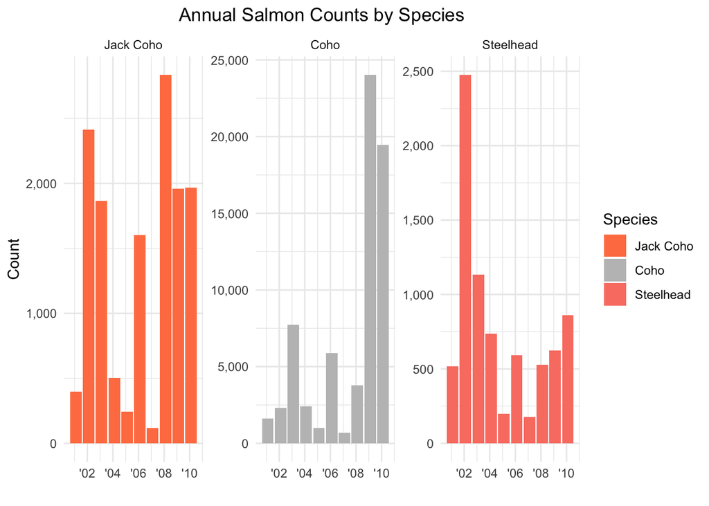

Figure 3: Annual Counts of Jack Coho, Coho and Steelhead Salmon in Willamette Falls, Oregon, 2001-2010.

```r
# render plot

plot3
```

- Coho salmon were significantly more abundant than other species in 2009 and 2010. The Coho salmon population exploded around this time, with considerably more salmon of this species recorded in 2009 and 2010 compared with other years.
- Jack Coho salmon appear to have resurgences and declines in population in different years.
- Steelhead salmon appear to have had a particularly abundant year in 2002, with stability or declines at lowers levels in other years.
- Cyclicality is not apparent for Coho and Steelhead salmon, though may be relevant for Jack Coho.

## Data & Image Sources

<sup>1</sup>Columbia River DART, Columbia Basin Research, University of Washington. 2021. Adult Passage Graphics & Text. Available from http://www.cbr.washington.edu/dart/query/adult_graph_text

<sup>2</sup>Federal agencies release final Columbia River System Operations environmental impact state. (n.d.). Northwestern Division. Retrieved February 7, 2021, from https://www.nwd.usace.army.mil/Media/News-Releases/Article/2295683/federal-agencies-release-final-columbia-river-system-operations-environmental-i/

<sup>3</sup> Willamette Falls Fish Counts. (n.d.). Oregon Department of Fish & Wildlife. Retrieved February 7, 2021, from http://www.cbr.washington.edu/dart/query/adult_graph_text